# trees_graphs_markdown

Don Radcliffe

4/27/2021

# Introduction

This script is for graphing the stand structure variables basal area, density, and qmd, in order to get a better sense of the study site for brainstorming analyses. I haven’t processed any other response variables yet but figured that these three would be best for a first pass on thinking about how to process and visualize the rest of the data. Karen, if you could pass along the link to the Lake Roosevelt data as well, all the visualizations below are from Stehekin only. The Lake Roosevelt data should be easy to integrate into these graphs provided there aren’t any major formatting differences.

This sort of graphing exercise is about as far as we’re planning to go for the DNR report; we’re planning on doing pretty basic regressions of important response variables with time since treatment, combining data from multiple relevant studies including this one. Those graphs will probably broken up by treatment type as I’ve done with the first set of graphs here.

Note, however, that my ideal plan for our nps fire fx manuscript would to address questions like:

1. What are the tradeoffs between retreating a stand and treating an untreated stand?  
   1a) What is the longevity of a treatment when compared with the baseline of a comparible untreated stand?
2. How many treatments does it take to reach a point of diminishing returns?

I haven’t thought in depth about whether we can actually answer these questions with these data, or how specifically to operationalize the analyses; the graphs below will give us all a good starting point for brainstorming. It’s going to be a long time before I make big progress on these analyses, likely more than a year, because I have two other publications and a proposal that are more time-pressing. In the meantime I will hopefully take a timeseries analysis class and learn more than my current casual knowledge about optimization procedures like linear programming.

Let me know if you have any feedback on how to better visualize these data, I consider these graphs exploratory in that I tried to squeeze in more information than we’d put in a final product. And there may well be better ways to go about this.

Note that several plots had the majority of their trees’ dbh values listed as NA, especially in the immediate post-treatment reads but not limited to those. Whether or not the dbh was listed as NA did not seem related to other values like height. I’ve filtered out any plots with more than four NAs in the dbh column, in my data_processing script. I’m not sure if this approach makes sense, but I can easily adjust that after talking to Karen about the meaning of those NAs.

I definitely made some editorial decisions along the way, so if you’d like to play around with these visualizations yourself, feel free to clone the [repo](https://github.com/don-radcliffe/nps_fx) and check out the scripts there; everything is set up with the here() package so that it should run for you without adjustment.

# Setup and formatting code

```r
require(here)
require(dplyr)
require(ggplot2)

import_dir_tg <- here::here('data', 'data_tidy')
export_dir_tg <- here::here('plots', 'trees')

trees_raw <- read.csv(file.path(import_dir_tg, 'trees_tidy.csv'), stringsAsFactors = TRUE)
plot_data_raw <- read.csv(file.path(import_dir_tg, 'plot_visit_data.csv'), stringsAsFactors = TRUE)
```

```r
trees <- full_join(trees_raw, plot_data_raw, by = 'plot_visit') %>%
  ## -2 means early pretreatment read, only want to use most recent pretreatment read
  filter(years_post != -2) %>%
  ## There are some weird zeros in the data that
  filter(status == 'l') %>%
  ## Arrange treatments in some kind of order.
  mutate(treatment = factor(treatment, levels = c('pretreatment_current', 'pileburn',
                               'burn', 'thin',
                               'thin_burn', 'thin_burn_burn',
                               'thin_thin_burn', 'thin_thin_burn_burn','thin_thin_burn_burn_burn'))) %>%
  ## Arrange areas by proximity to Stehekin,
  ## don't see Bullion on my map, maybe it replaced a problematic older name that's farthest away.
  mutate(area = factor(area, levels = c('weaver', 'boulder', 'orchard rainbow', 'company creek',
                                        'lower mcgregor', 'mcgregor', 'upper mcgregor', 'bullion')))
str(trees)
```

```
## 'data.frame':    269 obs. of  16 variables:
##  $ plot_visit       : Factor w/ 352 levels "nc01_1996_-2_-2",..: 2 3 4 5 6 8 9 10 11 12 ...
##  $ status           : Factor w/ 2 levels "d","l": 2 2 2 2 2 2 2 2 2 2 ...
##  $ basal_area       : num  15.5 14.7 15.3 16.4 15.6 23 1.6 19.2 19 18.6 ...
##  $ density          : int  290 250 250 250 250 680 560 540 530 490 ...
##  $ qmd              : num  26.1 27.3 27.9 28.9 28.2 20.8 6.1 21.3 21.4 22 ...
##  $ plot             : Factor w/ 50 levels "nc01","nc02",..: 1 1 1 1 1 2 2 2 2 2 ...
##  $ area             : Factor w/ 8 levels "weaver","boulder",..: 3 3 3 3 3 3 3 3 3 3 ...
##  $ year             : int  2000 2001 2003 2004 2007 2000 2001 2003 2004 2007 ...
##  $ date             : Factor w/ 244 levels "1996/05/29","1996/06/01",..: 58 62 84 94 133 57 63 84 94 135 ...
##  $ treatment_code   : int  -1 2 4 4 4 -1 2 4 4 4 ...
##  $ years_post       : int  -1 1 1 2 5 -1 1 10 2 15 ...
##  $ treatment        : Factor w/ 9 levels "pretreatment_current",..: 1 4 5 5 5 1 4 5 5 5 ...
##  $ burns            : int  0 0 1 1 1 0 0 1 1 1 ...
##  $ thins            : int  0 1 1 1 1 0 1 1 1 1 ...
##  $ pileburns        : int  0 0 0 0 0 0 0 0 0 0 ...
##  $ monitoring_status: Factor w/ 40 levels "-1pre-1","-2pre-2",..: 1 9 16 17 18 1 9 19 17 20 ...
```

# Graphing code

```r
## Theme for graphing.
simpletheme <- theme(panel.grid.major = element_blank(),
                     panel.grid.minor = element_blank(),
                     panel.background = element_blank()) +
  theme(plot.title = element_text(hjust = 0.5)) +
  theme(axis.ticks = element_blank()) +
  theme(axis.line = element_line(size = 0.2, color = 'black')) +
  theme(legend.key=element_blank(), legend.background=element_blank())

## Common color scheme for areas
area_colors <- c('weaver' = 'gray0', 'boulder' = 'gray8', 'orchard rainbow' = 'gray16', 'company creek' = 'gray24', 'lower mcgregor' = 'gray32', 'mcgregor' = 'gray40', 'upper mcgregor' = 'gray48', 'bullion' = 'gray56')

## And for treatments.
treatment_colors <- c('pretreatment_current' = 'dodgerblue3',
                      'pileburn' = 'purple3', 'burn' = 'red3', 'thin' = 'gold1',
                      'thin_burn' = 'gold3', 'thin_burn_burn' = 'tan4',
                      'thin_thin_burn' = 'gray60', 'thin_thin_burn_burn' = 'gray30', 'thin_thin_burn_burn_burn' = 'gray0')
```

For this first set of graphs, I’ve faceted out the different combinations of thinning and burning to visualize how important variables respond with time since different types of treatments. This way of thinking is most aligned with the fuels longevity report; it does a much better job of looking at time since treatment then the effects of the treatment itself.

I’ve colored the lines by the eight named areas (analagous to stands?). They’re in a gradient of darker gray for farther downvalley to lighter colors for farther upvalley, so that we can get some indication of the spatial spread of different treatments and of whether there are any systematic biases by location.

In all graphs below, I’ve set the y axis so that it cuts out some big outliers, because otherwise it gets even more difficult to distinguish different plots. But you’ll see the line coming in off the top of the graph. You’ll also notice some of the plots have an outlier point somewhere in their timeline and/or have some weird discontinuities in time. In all cases, I’ve left these in without looking for the source of the issue to see if Karen has any insights. I’ve made all the graphs really tall to spread out the lines as much as possible.

## Faceted graphs

### Function for faceted graphs

```r
gg_facet <- function(var) {
  yvar = enquo(var)
  ggplot(trees, aes(x = years_post, y = !!yvar, group = plot)) +
  geom_point(alpha = 0.5, size = 1.4) +
  geom_line(size = 1.1, aes(color = area)) +
  facet_grid(thins~burns, labeller = label_both) +
  scale_color_manual(values = area_colors) +
  theme_bw() +
  xlab('years after treatment combination')
}
```

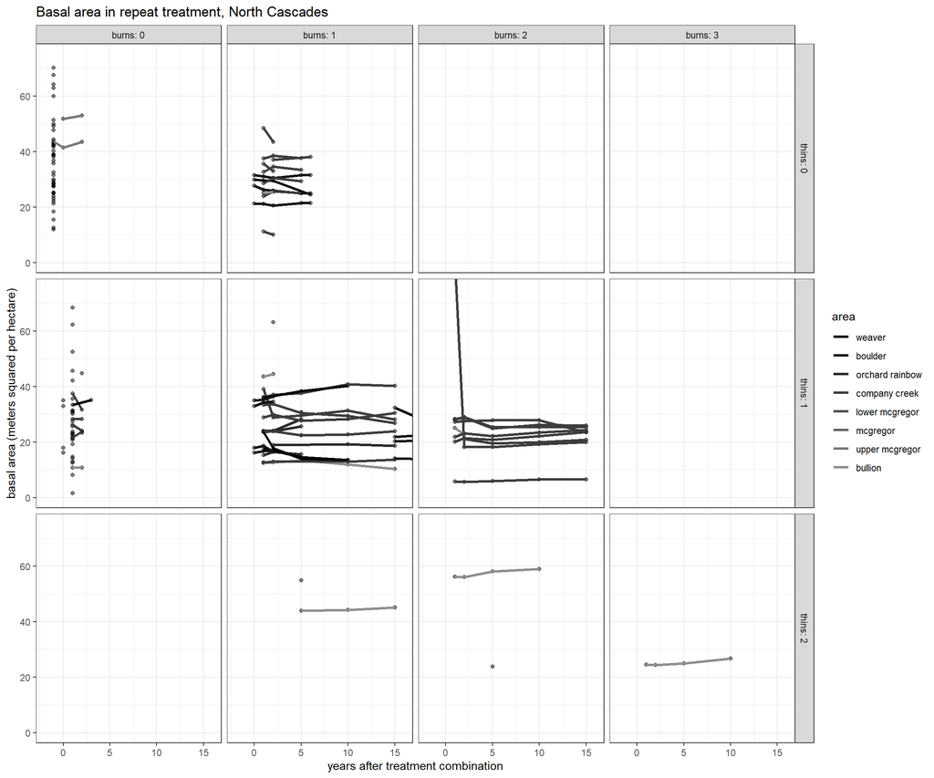

```r
basal_area <- gg_facet(basal_area) +
  ## Note my x scale cut off ten data points at the 20 years mark,
  ## mostly one thin one burn,
  ## to get better spread on most the data.
  coord_cartesian(xlim = c(-2,16), ylim = c(0,75)) +
  ggtitle('Basal area in repeat treatment, North Cascades') +
  ylab('basal area (meters squared per hectare)')
basal_area
```

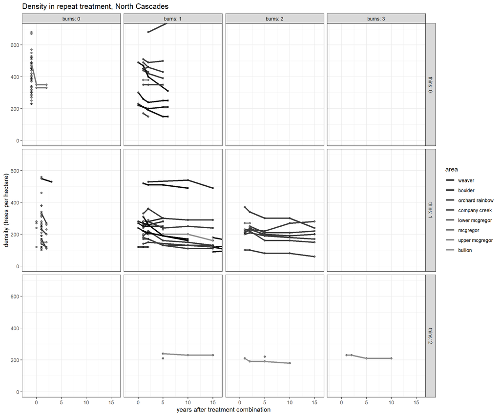

```r
density <- gg_facet(density) +
  coord_cartesian(xlim = c(-2, 16), ylim = c(0, 700)) +
  ggtitle('Density in repeat treatment, North Cascades') +
  ylab('density (trees per hectare)')
density
```

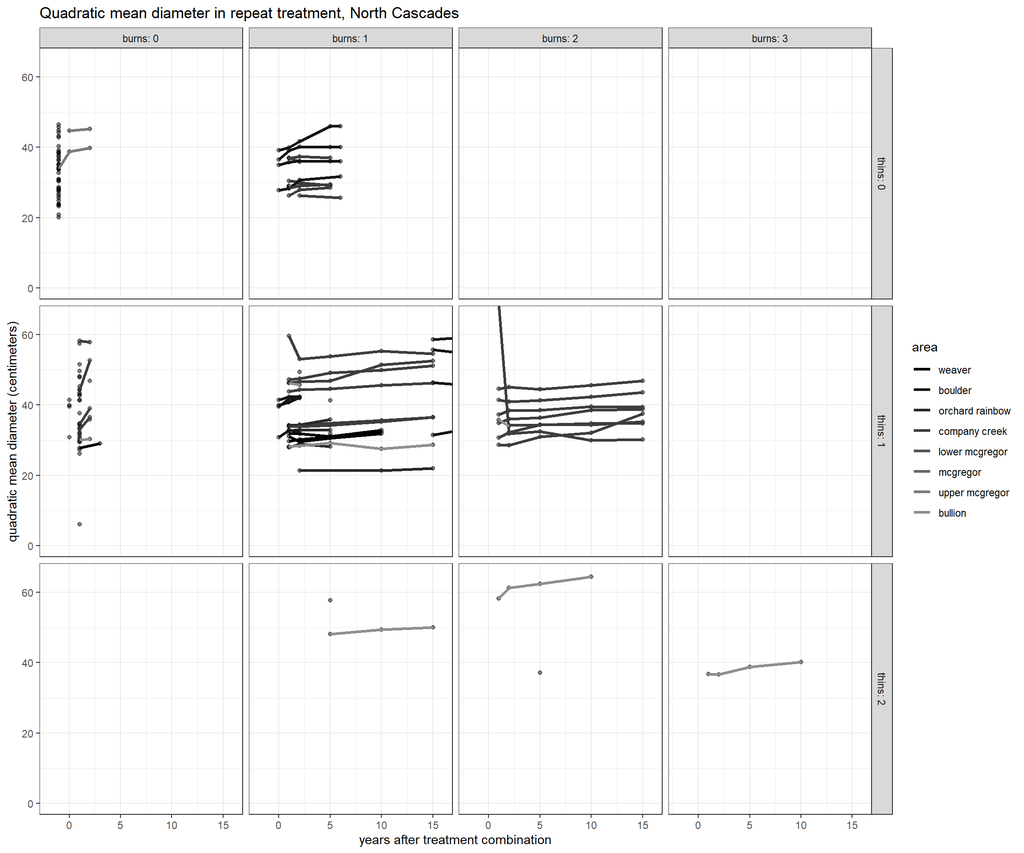

```r
qmd <- gg_facet(qmd) +
  coord_cartesian(xlim = c(-2, 16), ylim = c(0,65)) +
  ggtitle('Quadratic mean diameter in repeat treatment, North Cascades') +
  ylab('quadratic mean diameter (centimeters)')
qmd
```